# GEM500: Landscape Metrics - Disturbance

Jen Baron | University of British Columbia, Department of Forest and Conservation Sciences jenbaron@mail.ubc.ca

October 13, 2021

This lab is an adaptation in R of Exercises 5 & 6 in Turner, M. G. & Simard, M. Chapter 11: Using Spatial Statistics and Landscape Metrics to Compare Disturbance Mosaics (2nd Ed.) (2017).

In this lab, students will compare the spatial patterns of burned landscapes using alternative landscape metrics and analysis parameters (low vs. high thresholding, and choice of 4 vs. 8 neighborhood rule).

*Learning Outcomes*

By the end of the lab, students will:

1. Describe and compare the landscape patterns created by fire in Greater Yellowstone (the same landscapes used in Part 1) using landscape metrics in FRAGSTATS and categorical data for disturbance patterns.
2. Interpret the output ecologically and evaluate the effects of different categorization schemes on the results.

# Introduction

Forest disturbance severity is often depicted in discrete classes on maps (often either 2 or 3 classes that represent high and low severity, along with undisturbed areas). The thresholds that are used to convert a continuous variable to a categorical measure of disturbance severity may influence the quantitative measures of disturbance patterns, including patch size, patch shape, connectivity of disturbed area, distance to edge, etc.

In this exercise, you will compute landscape metrics on categorical maps of fire severity using `landscapemetrics` and two different categorization schemes (Figure 11.3 in Ch 11 of LLE). The binary fire severity maps (burned vs. unburned) were created using the continuous maps of dNBR such that the maps labeled “low” include all areas that were burned (including high and low severity fire, defined here as dNBR > 170). The maps labeled “high” focus only on high-severity fire (defined here as dNBR > 600).

In this lab you will compute landscape metrics for fire patterns using categorical data analyzed in `landscapemetrics`. landscapemetrics is an R package for calculating landscape metrics for categorical landscape patterns in a tidy workflow. The package can be used as a drop-in replacement for FRAGSTATS (McGarigal et al. 2012), as it offers a reproducible workflow for landscape analysis in a single environment.

## Load packages

The first time you use a package you need to install it before you load it. To do this, use the command `install.packages("packagename")`.

```r
library(here)

#data manipulation & plotting
library(dplyr)
library(tidyr)
library(ggplot2)

#FRAGSTATS functions & raster data
library(landscapemetrics)
library(landscapetools)
library(raster)
```

# Read data

The data is in .tif format, so we’re going to read it in using the `raster` package in R.

`raster` is for reading, writing, manipulating, analyzing and modeling of spatial data. The package implements basic and high-level functions for raster data and for vector data operations.

```r
fire_1_high <- raster(here("fire_1_high.tif"))
fire_1_low <- raster(here("fire_1_low.tif"))
fire_2_high <- raster(here("fire_2_high.tif"))
fire_2_low <- raster(here("fire_2_low.tif"))
fire_3_high <- raster(here("fire_3_high.tif"))
fire_3_low <- raster(here("fire_3_low.tif"))
fire_4_high <- raster(here("fire_4_high.tif"))
fire_4_low <- raster(here("fire_4_low.tif"))
fire_5_high <- raster(here("fire_5_high.tif"))
fire_5_low <- raster(here("fire_5_low.tif"))
```

## Review data format

This is what our data format should look like (what we would input into FRAGSTATS):

- Row count (y): 165
- Column count (x): 165
- Background value: 99
- Cell size: 30
- Input data type: Raw ASCII grid
- 0 = unburned, 1 = burned and 99 = background

```r
fire_1_high
```

```
## class      : RasterLayer
## dimensions : 165, 165, 27225  (nrow, ncol, ncell)
## resolution : 30, 30  (x, y)
## extent     : 0, 4950, 0, 4950  (xmin, xmax, ymin, ymax)
## crs        : NA
## source     : fire_1_high.tif
## names      : fire_1_high
## values     : 0, 99  (min, max)
```

Let’s check what our background (NA) value is:

```r
NAvalue(fire_1_high)
```

```
## [1] -Inf
```

It should be 99, let’s fix this using the `raster::NAvalue()` function.

```r
NAvalue(fire_1_high) <- 99
NAvalue(fire_1_low) <- 99
NAvalue(fire_2_high) <- 99
NAvalue(fire_2_low) <- 99
NAvalue(fire_3_high) <- 99
NAvalue(fire_3_low) <- 99
NAvalue(fire_4_high) <- 99
NAvalue(fire_4_low) <- 99
NAvalue(fire_5_high) <- 99
NAvalue(fire_5_low) <- 99
```

# Visualize landscape

To visualize the landscape we can use the `plot()` function, or we can use `landscapetools::show_landscape` which allows us to plot a raster object using a theme for visualizing landscapes.

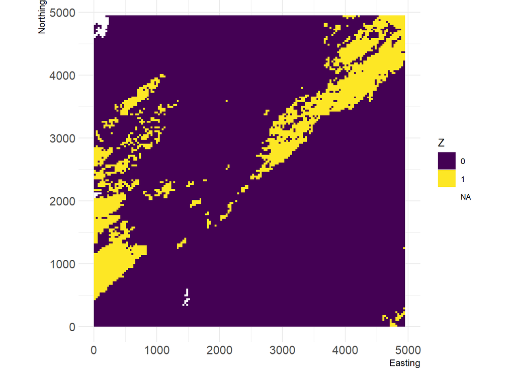

```r
show_landscape(fire_1_high, discrete=TRUE)
```

Plot all of the landscapes.

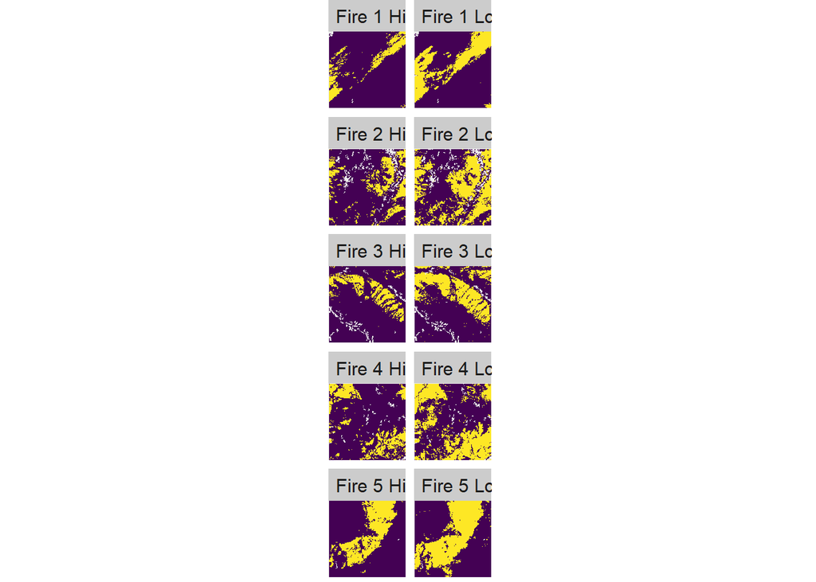

```r
landscapes <- list("Fire 1 High" = fire_1_high,
                    "Fire 1 Low" = fire_1_low,
                    "Fire 2 High" = fire_2_high,
                   "Fire 2 Low" = fire_2_low,
                   "Fire 3 High" = fire_3_high,
                   "Fire 3 Low" = fire_3_low,
                   "Fire 4 High" = fire_4_high,
                   "Fire 4 Low" = fire_4_low,
                   "Fire 5 High" = fire_5_high,
                   "Fire 5 Low" = fire_5_low)

show_landscape(landscapes, discrete=TRUE, n_row=5, n_col=2)
```

# Introduction to landscapemetrics

## Check landscape

To check if the data sets fulfill the basic requirements of the landscapemetrics package, you can use the `landscapemetrics::check_landscape` function.

```r
check_landscape(fire_1_high) #coordinate system not metric
```

```
##   layer crs units   class n_classes  OK
## 1     1  NA    NA integer         2 (?)
```

This output is telling us that there is no coordinate reference system or units in the dataset, so we must exercise caution when interpreting the units of the results.

## List all available metrics

`landscapemetrics` include a function to show you all available metrics and filter them according to the characteristics of the landscape they conceptually describe. For help, have a look at the help page of the ?`list_lsm()` function.

To show all metrics, you do not have to specify any argument of the function. However, if you want e.g. only all metrics at the patch level, you can specify the “level” argument. Several arguments can be combined.

```r
View(list_lsm()) #View opens a spreadsheet-style data viewer
list_lsm(level = "class", type = "area and edge metric") #show all area and edge metrics at the class level
```

```
## # A tibble: 11 x 5
##    metric    name                    type                 level function_name
##    <chr>     <chr>                   <chr>                <chr> <chr>
##  1 area_cv   patch area              area and edge metric class lsm_c_area_cv
##  2 area_mn   patch area              area and edge metric class lsm_c_area_mn
##  3 area_sd   patch area              area and edge metric class lsm_c_area_sd
##  4 ca        total (class) area      area and edge metric class lsm_c_ca
##  5 ed        edge density            area and edge metric class lsm_c_ed
##  6 gyrate_cv radius of gyration      area and edge metric class lsm_c_gyrate_cv
##  7 gyrate_mn radius of gyration      area and edge metric class lsm_c_gyrate_mn
##  8 gyrate_sd radius of gyration      area and edge metric class lsm_c_gyrate_sd
##  9 lpi       largest patch index     area and edge metric class lsm_c_lpi
## 10 pland     percentage of landscape area and edge metric class lsm_c_pland
## 11 te        total edge              area and edge metric class lsm_c_te
```

**List all “shape metric” on “class”- and “landscape”-level as well as all “diversity metrics” on “landscape”-level.**

## Calculate a single metric

All functions that calculate a single landscape metrics have a similar name structure. The first part of the function name “lsm_” stands for landscapemetric. The second part indicates the level, e.g. “lsm_p_” for patch level (correspondingly “*c*” for class- and “*l*” for landscape-level). Lastly, the third part is an abbreviation of the metric, e.g. lsm_p_area().

Many metrics have additional arguments that can be specified. For example,

- Neighbourhood specifies the number of directions in which cell adjacencies are considered as neighbours: 4 (rook’s case) or 8 (queen’s case). The default is 4.
- Direction specifies the number of directions in which patches should be connected: 4 (rook’s case) or 8 (queen’s case).

Note that these do not apply for every metric.

```r
lsm_p_area(landscape = fire_1_high) -> f1h.area
head(f1h.area) #head shows the first 6 rows
```

```
## # A tibble: 6 x 6
##   layer level class    id metric   value
##   <int> <chr> <int> <int> <chr>    <dbl>
## 1     1 patch     0     1 area      1.08
## 2     1 patch     0     2 area   2121.
## 3     1 patch     0     3 area      0.09
## 4     1 patch     0     4 area      4.77
## 5     1 patch     0     5 area      0.09
## 6     1 patch     0     6 area      0.09
```

```r
lsm_p_perim(landscape = fire_1_high) -> f1h.perim
tail(f1h.perim) #tail shows the last 6 rows
```

```
## # A tibble: 6 x 6
##   layer level class    id metric value
##   <int> <chr> <int> <int> <chr>  <dbl>
## 1     1 patch     1   110 perim    120
## 2     1 patch     1   111 perim    420
## 3     1 patch     1   112 perim    480
## 4     1 patch     1   113 perim    780
## 5     1 patch     1   114 perim    120
## 6     1 patch     1   115 perim    120
```

Because the output of all functions that calculate landscape metrics is type-stable, it is quite easy to combine several result tibbles. We can combine the previously created tibbles into one large result tibble using `dplyr::bind_rows()`

```r
bind_rows(f1h.area, f1h.perim)
```

```
## # A tibble: 230 x 6
##    layer level class    id metric   value
##    <int> <chr> <int> <int> <chr>    <dbl>
##  1     1 patch     0     1 area      1.08
##  2     1 patch     0     2 area   2121.
##  3     1 patch     0     3 area      0.09
##  4     1 patch     0     4 area      4.77
##  5     1 patch     0     5 area      0.09
##  6     1 patch     0     6 area      0.09
##  7     1 patch     0     7 area      0.09
##  8     1 patch     0     8 area      0.27
##  9     1 patch     0     9 area      0.09
## 10     1 patch     0    10 area      0.09
## # ... with 220 more rows
```

**For the “fire_1_high” data set, calculate the perimeter-area ratio (para) on patch level. Also, calculate the percentage of landscape of class (pland) and lastly the total edge (te) on landscape level and combine the metrics in a tibble**

## Calculate multipe metrics at once

It’s also possible to calculate several metrics at once. For this, the function `calculate_lsm()` can be used. There are several ways to select metrics. The function takes the same arguments as the previously introduced `list_lsm()` function. So, for example it is quite easy to calculate all patch level metrics. To see a progress report, you can set progress = TRUE.

However, we strongly recommend not to calculate a large number of metrics (“metric fishing expeditions”; Gustafson 2019), but rather think about which selected metrics are the most meaningful for your research question.

```r
patch_level <- calculate_lsm(landscape = fire_1_high,
                             level = "patch", type = "area and edge metric",
                             progress = TRUE)
```

```
##
> Progress metrics:  1 / 3
> Progress metrics:  2 / 3
> Progress metrics:  3 / 3
```

```r
patch_level
```

```
## # A tibble: 345 x 6
##    layer level class    id metric   value
##    <int> <chr> <int> <int> <chr>    <dbl>
##  1     1 patch     0     1 area      1.08
##  2     1 patch     0     2 area   2121.
##  3     1 patch     0     3 area      0.09
##  4     1 patch     0     4 area      4.77
##  5     1 patch     0     5 area      0.09
##  6     1 patch     0     6 area      0.09
##  7     1 patch     0     7 area      0.09
##  8     1 patch     0     8 area      0.27
##  9     1 patch     0     9 area      0.09
## 10     1 patch     0    10 area      0.09
## # ... with 335 more rows
```

Additionally, the function can take a vector with function names as “what” argument to calculate selected metrics.

```r
multiple_metrics <- calculate_lsm(landscape = fire_1_high,
                                  what = c("lsm_p_area", "lsm_p_para"),
                                  progress = TRUE)
```

```
##
> Progress metrics:  1 / 2
> Progress metrics:  2 / 2
```

```r
multiple_metrics
```

```
## # A tibble: 230 x 6
##    layer level class    id metric   value
##    <int> <chr> <int> <int> <chr>    <dbl>
##  1     1 patch     0     1 area      1.08
##  2     1 patch     0     2 area   2121.
##  3     1 patch     0     3 area      0.09
##  4     1 patch     0     4 area      4.77
##  5     1 patch     0     5 area      0.09
##  6     1 patch     0     6 area      0.09
##  7     1 patch     0     7 area      0.09
##  8     1 patch     0     8 area      0.27
##  9     1 patch     0     9 area      0.09
## 10     1 patch     0    10 area      0.09
## # ... with 220 more rows
```

**Calculate all shape metrics on the class level for the fire_1_high dataset and additionally 3 metrics of choice (one from each level) using calculate_lsm (2 seperate function calls).**

# Exercises 5 & 6: Quantifying Fire Patterns

For each of the ten landscapes (2 thresholds × 5 reps = 10 landscapes), you will use `landscapemetrics` to characterize the spatial patterns of the burned landscapes.

Choosing which metrics to quantify in any analysis is an important step, as each metric provides information about some aspect of pattern, and many metrics are redundant. **You will include the five metrics listed below in your selection plus five others of your own choosing**. You must have a rationale for selection of each and should choose indices that you think will have different (complementary) information about the spatial patterns.

- Landscape-level metrics: edge density (ED) and contagion (CONTAG)
- Class-level metrics: proportion of landscape occupied (PLAND), number of patches (NP), and mean patch size (AREA_MN)

Once you have generated the output for all ten landscapes, compare the metric results for each of the classification schemes using either graphs or a table.

Create a list of all the dataframes so we can calculate the landscape metrics as a batch:

```r
fire <- as.list(fire_1_high,
                fire_1_low,
                fire_2_high,
                fire_2_low,
                fire_3_high,
                fire_3_low,
                fire_4_high,
                fire_4_low,
                fire_5_high,
                fire_5_low)
```

## Calculate metrics

**Insert your additional metrics here. You can add to the list of existing metrics and/or create a new dataset with patch-level metrics**

```r
fire.c8 <- calculate_lsm(landscape=fire, what = c("lsm_c_pland", "lsm_c_np", "lsm_c_area_mn"), progress = TRUE, neighbourhood = 8, directions = 8)
```

```
##
> Progress nlayers:  1 / 10
> Progress nlayers:  2 / 10
> Progress nlayers:  3 / 10
> Progress nlayers:  4 / 10
> Progress nlayers:  5 / 10
> Progress nlayers:  6 / 10
> Progress nlayers:  7 / 10
> Progress nlayers:  8 / 10
> Progress nlayers:  9 / 10
> Progress nlayers:  10 / 10
```

```r
fire.l8 <- calculate_lsm(landscape=fire, what = c("lsm_l_ed", "lsm_l_contag"), progress=TRUE, neighbourhood = 8, directions = 8)
```

```
##
> Progress nlayers:  1 / 10
> Progress nlayers:  2 / 10
> Progress nlayers:  3 / 10
> Progress nlayers:  4 / 10
> Progress nlayers:  5 / 10
> Progress nlayers:  6 / 10
> Progress nlayers:  7 / 10
> Progress nlayers:  8 / 10
> Progress nlayers:  9 / 10
> Progress nlayers:  10 / 10
```

**Q1 Provide the rational for each metric that was selected for the analysis (included the new one you selected). Why might each metric tell you something different about the burned landscape?**

Let’s take a look at the outputs.

```r
head(fire.c8)
```

```
## # A tibble: 6 x 6
##   layer level class    id metric  value
##   <int> <chr> <int> <int> <chr>   <dbl>
## 1     1 class     0    NA area_mn 43.8
## 2     1 class     1    NA area_mn  4.47
## 3     1 class     0    NA np      49
## 4     1 class     1    NA np      66
## 5     1 class     0    NA pland   87.9
## 6     1 class     1    NA pland   12.1
```

```r
head(fire.l8)
```

```
## # A tibble: 6 x 6
##   layer level     class    id metric value
##   <int> <chr>     <int> <int> <chr>  <dbl>
## 1     1 landscape    NA    NA contag  61.3
## 2     1 landscape    NA    NA ed      31.4
## 3     2 landscape    NA    NA contag  46.3
## 4     2 landscape    NA    NA ed      30.0
## 5     3 landscape    NA    NA contag  46.0
## 6     3 landscape    NA    NA ed      55.3
```

Because we ran this as a batch, we lost the information contained in the file names. Let’s add it back in and format the data for plotting.

```r
#Add file names back in
fire.c8 <- fire.c8 %>%
     mutate(layer = recode(layer, "1" = "fire_1_high",
         "2" = "fire_1_low",
         "3" = "fire_2_high",
         "4" = "fire_2_low",
         "5" = "fire_3_high",
         "6" = "fire_3_low",
         "7" = "fire_4_high",
         "8" = "fire_4_low",
         "9" = "fire_5_high",
         "10" = "fire_5_low"))
fire.l8 <- fire.l8 %>%
     mutate(layer = recode(layer, "1" = "fire_1_high",
         "2" = "fire_1_low",
         "3" = "fire_2_high",
         "4" = "fire_2_low",
         "5" = "fire_3_high",
         "6" = "fire_3_low",
         "7" = "fire_4_high",
         "8" = "fire_4_low",
         "9" = "fire_5_high",
         "10" = "fire_5_low"))
#Make layer, metric & class a factor
fire.c8$layer <- as.factor(fire.c8$layer)
fire.c8$class <- as.factor(fire.c8$class)
fire.c8$metric <- as.factor(fire.c8$metric)
fire.l8$layer <- as.factor(fire.l8$layer)
fire.l8$metric <- as.factor(fire.l8$metric)
#Separate the layer names into different columns
fire.c8 <- fire.c8 %>%
  separate(col=layer, into = c("fire", "landscape", "threshold"), sep="_") %>%
  mutate(rule = "8")
fire.l8 <- fire.l8 %>%
  separate(col=layer, into = c("fire", "landscape", "threshold"), sep="_") %>%
  mutate(rule = "8")
```

## Visualize results

**Landscape Level**

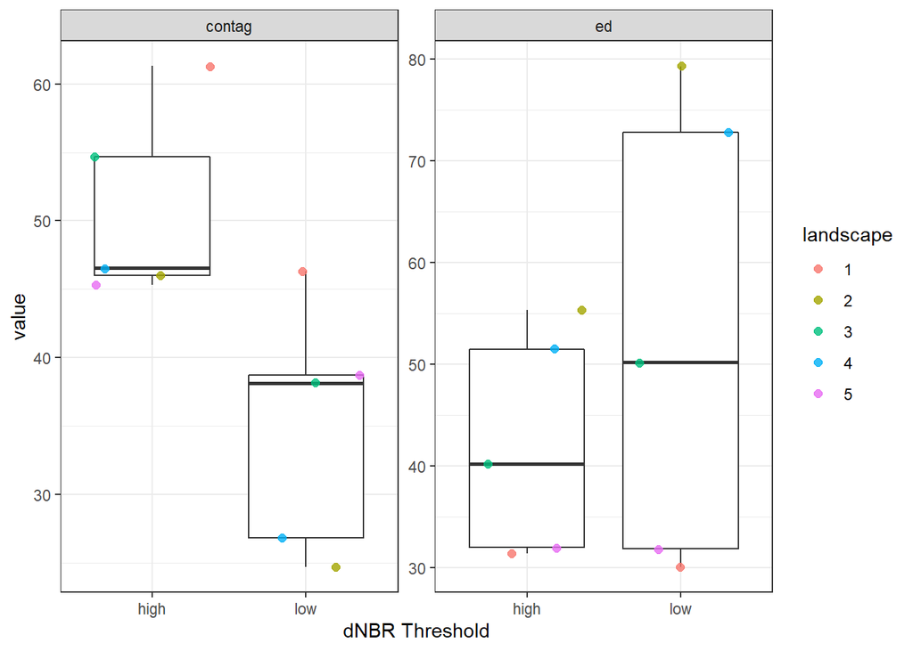

```r
ggplot(fire.l8, aes(x=threshold, y=value)) +
  geom_boxplot(outlier.shape = NA) +
  geom_jitter(aes(col=landscape), size=2, alpha=0.8) +
  facet_wrap(metric~., scales="free_y") +
  xlab("dNBR Threshold") +
  theme_bw()
```

**Class Level**

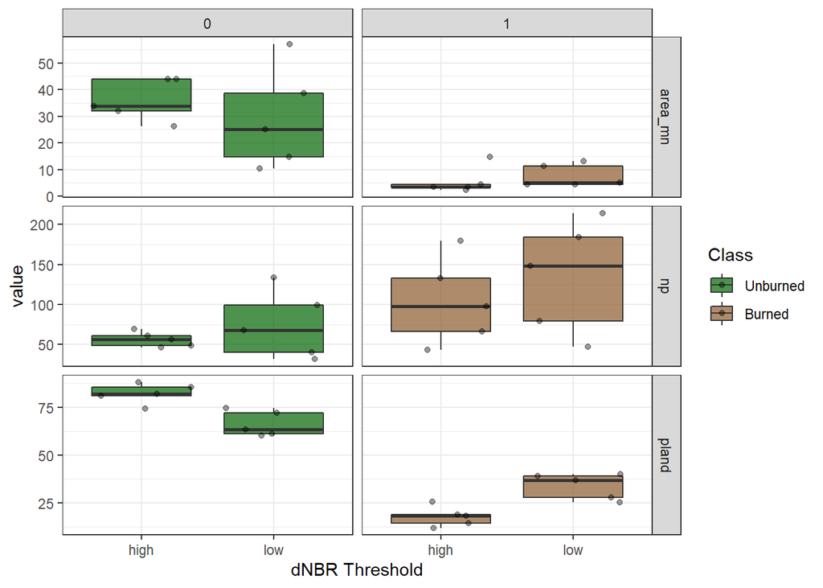

```r
ggplot(fire.c8, aes(x=threshold, y=value, fill=class)) +
  geom_boxplot(alpha = 0.7, outlier.shape=NA) +
  geom_jitter(alpha=0.4) +
  facet_grid(metric~class, scales="free_y") +
  scale_fill_manual(values=c("darkgreen", "tan4"),
                       name="Class",
                       labels=c("Unburned", "Burned")) +
  xlab("dNBR Threshold") +
  theme_bw()
```

**Q2 Briefly describe the spatial pattern of the landscape that used the low dNBR vs. the high dNBR threshold. How did this affect the quantitative estimates of burn patterns?**

## Neighbor rule

**Re-run the analysis using the 4- and 8- neighbour rules and compare the outputs.**

**Q3 Briefly describe the spatial patterns of the landscape that used the 8-cell neighborhood rule vs. the 4-cell neighborhood rule. How did this affect the quantitative estimates of burn patterns? Did all metrics change in the same way? Why or why not?**

**Q4 Considering the choice of metrics, the choice of threshold level, and the choice of neighborhood rule, how does this affect the ecological interpretation of the burned patterns on the landscape?**

# Save Outputs

Let’s save our outputs as .csv files the same way we would with FRAGSTATS.

```r
write.csv(fire.c8, "fire_class_8.csv")
write.csv(fire.l8, "fire_landscape_8.csv")
```

# Conclusions

Existing software to calculate landscape metrics has several constraints, such as being limited to a single platform, not being open-source or involving a complicated integration into large workflows. `landscapemetrics` overcomes many constraints of existing landscape metric software. If you are interested in learning more about `landscapemetrics` and it’s applications in landscape ecology, see Hesselbarth, M. H. K., Sciaini, M., With, K. A., Wiegand, K., & Nowosad, J. (2019). landscapemetrics: An open‐source R tool to calculate landscape metrics. Ecography, 42(10), 1648–1657. https://doi.org/10.1111/ecog.04617.

# Session Details

We can use `citation()` to cite R and R packages.

```r
citation("landscapemetrics")
```

```
##
## Software note, substituting the version of the application that you
## used for ‘version 0’.
##
##   Hesselbarth, M.H.K., Sciaini, M., With, K.A., Wiegand, K., Nowosad,
##   J. 2019. landscapemetrics: an open-source R tool to calculate
##   landscape metrics. - Ecography 42:1648-1657(ver. 0).
##
## A BibTeX entry for LaTeX users is
##
##   @Article{,
##     title = {landscapemetrics: an open-source R tool to calculate landscape metrics},
##     author = {Maximilian H.K. Hesselbarth and Marco Sciaini and Kimberly A. With and Kerstin Wiegand and Jakub Nowosad},
##     journal = {Ecography},
##     volume = {42},
##     year = {2019},
##     pages = {1648-1657},
##   }
```

```r
citation("raster")
```

```
##
##
##   Robert J. Hijmans (2021). raster: Geographic Data Analysis and
##   Modeling. R package version 3.4-10.
##   https://CRAN.R-project.org/package=raster
##
## A BibTeX entry for LaTeX users is
##
##   @Manual{,
##     title = {raster: Geographic Data Analysis and Modeling},
##     author = {Robert J. Hijmans},
##     year = {2021},
##     note = {R package version 3.4-10},
##     url = {https://CRAN.R-project.org/package=raster},
##   }
```

```r
Sys.time()
```

```
## [1] "2021-10-14 11:14:11 PDT"
```